# act_report

## Report: act_report

- Create a **250-word-minimum written report** called "act_report.pdf" or "act_report.html" that communicates the insights and displays the visualization(s) produced from your wrangled data. This is to be framed as an external document, like a blog post or magazine article, for example.
- After gathering, assessing, and cleaning data from the WeRateDogs twitter page, I conducted an analysis to gain insights. The final dataset included features such as favorite count, retweet count, tweet text, dog breed, image URL, and image prediction. The features that were most interesting to me were retweet count, favorite count, rating, dog breed, prediction, and confidence percentage.
- The analysis revealed that "pupper" is the most commonly tweeted breed in the dataset. In terms of dog types, "floofers" were found to be less common in comparison to "pupper" "doggos" and "puppos". However, The analysis revealed that "floofer" was found to have the highest average rating among the different dog breeds and types. This trend may also be attributed to the fact that the number of "floofers" in the dataset was significantly lower than that of other breeds and types, which may have led to a higher concentration of highly rated dogs.
- The analysis of the WeRateDogs twitter data revealed a strong linear relationship between favorite count and retweet count. This indicates that as the number of favorites on a tweet increases, the number of retweets also increases proportionally. This correlation can be visualized through a scatter plot where the dots are plotted for the tweets and the x-axis represents the favorite count and the y-axis represents the retweet count. As the dots move towards the right, the number of favorites increase and as the dots move upwards, the number of retweets increase. The linear pattern seen on the scatter plot confirms the positive relationship between the two variables.
- It's important to note that a linear relationship between those variables doesn't imply causality, it just implies that there is a positive correlation between them. Additionally, other factors such as the timing of the tweet, the content of the tweet, and audience engagement could also impact the number of favorites and retweets, and more detailed analysis and visualization should be done to understand the correlation better.

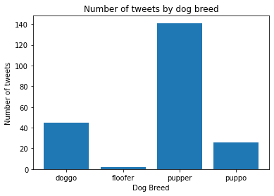

```python
import pandas as pd
import numpy as np
from datetime import datetime
import matplotlib
import matplotlib.pyplot as plt
%matplotlib inline
twitter_data = pd.read_csv('twitter_archive_master.csv', encoding = 'utf-8')
breed_counts = twitter_data.groupby('dog_type').size().reset_index(name='counts')

# Plot the data
plt.bar(breed_counts['dog_type'], breed_counts['counts'])
plt.xlabel('Dog Breed')
plt.ylabel('Number of tweets')
plt.title('Number of tweets by dog breed')
plt.show()
```

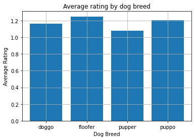

```python
# Create a new column 'rating' that calculates the rating as rating_numerator/rating_denominator
twitter_data['rating'] = twitter_data['rating_numerator']/twitter_data['rating_denominator']

# Group the data by dog_type and calculate the mean rating for each breed
breed_ratings = twitter_data.groupby('dog_type')['rating'].mean().reset_index()

# Plot the data
plt.bar(breed_ratings['dog_type'], breed_ratings['rating'])
plt.xlabel('Dog Breed')
plt.ylabel('Average Rating')
plt.title('Average rating by dog breed')
plt.grid()
plt.show()
```

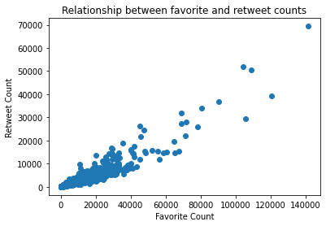

```python
from scipy.stats import linregress
# Create a scatter plot of the favorite_count and retweet_count columns
plt.scatter(twitter_data['favorite_count'], twitter_data['retweet_count'])
plt.xlabel('Favorite Count')
plt.ylabel('Retweet Count')
plt.title('Relationship between favorite and retweet counts')
plt.show()
```